# Homework 4

In this section we study the different groups of people, based on age ranges. First we set the evidence of a single age range, then we group ranges that report the same value for the specific variable we are analyzing.

### Clinical stage

The first variable we take in consideration is `Clinical Stage`. We obtain 7 age range, as we can see in the graphs below.

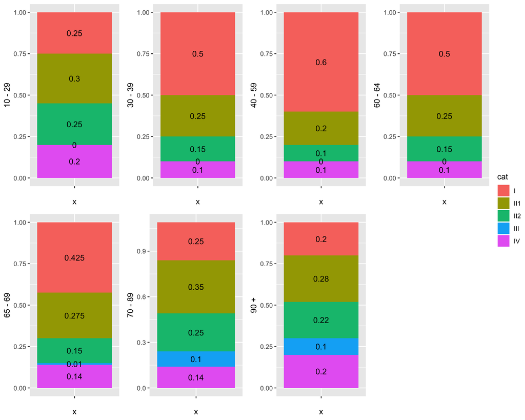

By visual inspection, we notice that age ranges `30-39, 40-59, 60-64` have a more similar distribution to the `alive` group, showing an higher probability to have `clinical stage` = `I` or `II1`.

As opposite, the first groups `10-29` and the group of people `65-69, 70-89, 90+`, show a behaviour more comparable to the group having `death` as `5YearsResult`, this is, having a lower probability to have `clinical stage` = `I` or `II1`, and an higher one to have `clinical stage` = `II2`, `III` or `IV`